# yangy22_FinalHomeworkCode_02

## What is the probability that she will hear exactly 3 calls in a session?

```r
z <- 3
(probset2 <- dpois(z, l))
```

```
## [1] 0.0001720701
```

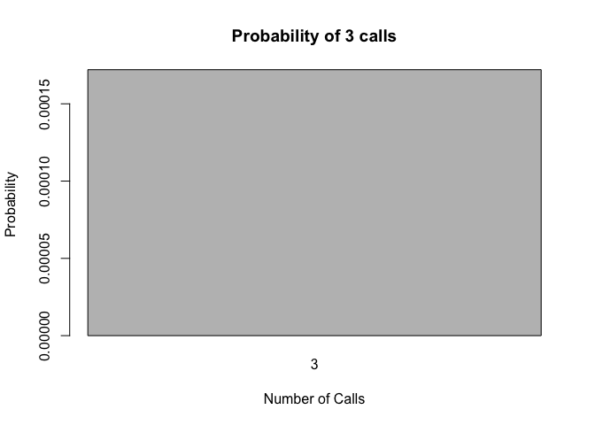

```r
barplot(probset2, names.arg = z, space = 0, xlab = "Number of Calls", ylab = "Probability", main = "Probability of 3 calls")
```

## Plot the relevant Poisson mass function over the values in range 0 ≤ x ≤ 30

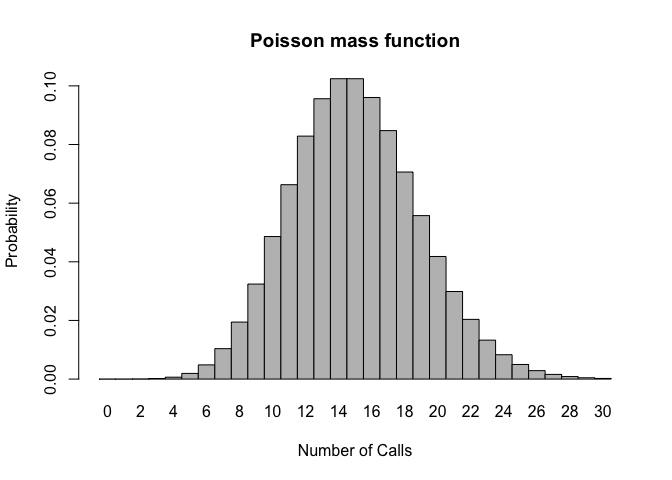

```r
a <- 0:30
probset3 <- dpois(a, l) # probabilities of number of calls from 0 to 30
barplot(probset3, names.arg = a, space = 0, xlab = "Number of Calls", ylab = "Probability", main = "Poisson mass function")
```

## Simulate 104 results from this distribution (i.e., 2 years of Saturday monitoring sessions).

```r
b <- rpois(104, 15) # rpois(n, lambda). n is number of trials
```

## Plot the simulated results using hist() and use xlim() to set the horizontal limits to be from 0 to 30. How does your histogram compare to the shape of the probability mass function you plotted above?

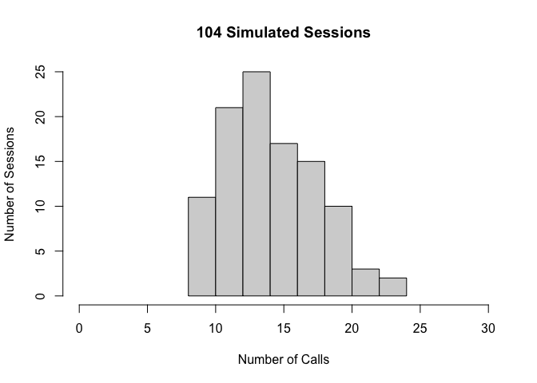

```r
hist(b, xlim = c(0,30), main = "104 Simulated Sessions", xlab = "Number of Calls", ylab = "Number of Sessions" )
```

The histogram represents 104 random trials so it is not as smooth as the distribution that the probability mass function plotted above. The small sample size means that we will not capture the rare events at either end of the poisson distribution and the occurances will not match up perfectly to probability.

Reflection: I learned a lot about how to use Poisson distribution and how to label and manipulate graphs. I liked Ritika’s comments about putting the whole line in parenthesis (probset1 <- dpois(y, l)) so I don’t have to put in probset1 again. I will be using this in the future. I also removed the repeated l = 15 because it would stay the same throughout. I did keep all my different variables because I like to see them all in the environment and its easier for me to keep track. I had trouble telling all the r commands apart but the bookdown website made things really clear. I like it more than the help page.

Poisson distribution: https://bookdown.org/gabriel_butler/ECON41Labs/tutorial-5-the-poisson-distribution.html  
TOC https://bookdown.org/yihui/rmarkdown/html-document.html